# 3MTT_CAPSTONE

```python
#import our Libraries
import pandas as pd
import numpy as np
import seaborn as sns

import matplotlib.pyplot as plt
import matplotlib.mlab as mlab
import matplotlib
plt.style.use('ggplot')
from matplotlib.pyplot import figure

%matplotlib inline
matplotlib.rcParams['figure.figsize'] = (12,8)

#reading the data
df = pd.read_csv(r'C:\Users\USER\Desktop\codschooadf\dataSets\worldometer_data.csv')
```

```python
df.value_counts().sum()
```

```
3
```

```python
df.isnull().sum()
```

```
Country/Region        0
Continent             1
Population            1
TotalCases            0
NewCases            205
TotalDeaths          21
NewDeaths           206
TotalRecovered        4
NewRecovered        206
ActiveCases           4
Serious,Critical     87
Tot Cases/1M pop      1
Deaths/1M pop        22
TotalTests           18
Tests/1M pop         18
WHO Region           25
dtype: int64
```

```python
df.describe()
```

|  | Population | TotalCases | NewCases | TotalDeaths | NewDeaths | TotalRecovered | NewRecovered | ActiveCases | Serious,Critical | Tot Cases/1M pop | Deaths/1M pop | TotalTests | Tests/1M pop |
| --- | --- | --- | --- | --- | --- | --- | --- | --- | --- | --- | --- | --- | --- |
| count | 2.080000e+02 | 2.090000e+02 | 4.000000 | 188.000000 | 3.000000 | 2.050000e+02 | 3.000000 | 2.050000e+02 | 122.000000 | 208.000000 | 187.000000 | 1.910000e+02 | 191.000000 |
| mean | 3.041549e+07 | 9.171850e+04 | 1980.500000 | 3792.590426 | 300.000000 | 5.887898e+04 | 1706.000000 | 2.766433e+04 | 534.393443 | 3196.024038 | 98.681176 | 1.402405e+06 | 83959.366492 |
| std | 1.047661e+08 | 4.325867e+05 | 3129.611424 | 15487.184877 | 451.199512 | 2.566984e+05 | 2154.779803 | 1.746327e+05 | 2047.518613 | 5191.986457 | 174.956862 | 5.553367e+06 | 152730.591240 |
| min | 8.010000e+02 | 1.000000e+01 | 20.000000 | 1.000000 | 1.000000 | 7.000000e+00 | 42.000000 | 0.000000e+00 | 1.000000 | 3.000000 | 0.080000 | 6.100000e+01 | 4.000000 |
| 25% | 9.663140e+05 | 7.120000e+02 | 27.500000 | 22.000000 | 40.500000 | 3.340000e+02 | 489.000000 | 8.600000e+01 | 3.250000 | 282.000000 | 6.000000 | 2.575200e+04 | 8956.500000 |
| 50% | 7.041972e+06 | 4.491000e+03 | 656.000000 | 113.000000 | 80.000000 | 2.178000e+03 | 936.000000 | 8.990000e+02 | 27.500000 | 1015.000000 | 29.000000 | 1.357020e+05 | 32585.000000 |
| 75% | 2.575614e+07 | 3.689600e+04 | 2609.000000 | 786.000000 | 449.500000 | 2.055300e+04 | 2538.000000 | 7.124000e+03 | 160.250000 | 3841.750000 | 98.000000 | 7.576960e+05 | 92154.500000 |
| max | 1.381345e+09 | 5.032179e+06 | 6590.000000 | 162804.000000 | 819.000000 | 2.576668e+06 | 4140.000000 | 2.292707e+06 | 18296.000000 | 39922.000000 | 1238.000000 | 6.313960e+07 | 995282.000000 |

```python
df.isnull().sum()
```

```
Country/Region        0
Continent             1
Population            1
TotalCases            0
NewCases            205
TotalDeaths          21
NewDeaths           206
TotalRecovered        4
NewRecovered        206
ActiveCases           4
Serious,Critical     87
Tot Cases/1M pop      1
Deaths/1M pop        22
TotalTests           18
Tests/1M pop         18
WHO Region           25
dtype: int64
```

```python
#DATA CLEANING
df['Continent']=df['Continent'].fillna(df['Continent'].mode()[0])
```

```python
df.isnull().sum()
```

```
Country/Region        0
Continent             0
Population            1
TotalCases            0
NewCases            205
TotalDeaths          21
NewDeaths           206
TotalRecovered        4
NewRecovered        206
ActiveCases           4
Serious,Critical     87
Tot Cases/1M pop      1
Deaths/1M pop        22
TotalTests           18
Tests/1M pop         18
WHO Region           25
dtype: int64
```

```python
df.head()
```

|  | Country/Region | Continent | Population | TotalCases | NewCases | TotalDeaths | NewDeaths | TotalRecovered | NewRecovered | ActiveCases | Serious,Critical | Tot Cases/1M pop | Deaths/1M pop | TotalTests | Tests/1M pop | WHO Region |
| --- | --- | --- | --- | --- | --- | --- | --- | --- | --- | --- | --- | --- | --- | --- | --- | --- |
| 0 | USA | North America | 3.311981e+08 | 5032179 | NaN | 162804.0 | NaN | 2576668.0 | NaN | 2292707.0 | 18296.0 | 15194.0 | 492.0 | 63139605.0 | 190640.0 | Americas |
| 1 | Brazil | South America | 2.127107e+08 | 2917562 | NaN | 98644.0 | NaN | 2047660.0 | NaN | 771258.0 | 8318.0 | 13716.0 | 464.0 | 13206188.0 | 62085.0 | Americas |
| 2 | India | Asia | 1.381345e+09 | 2025409 | NaN | 41638.0 | NaN | 1377384.0 | NaN | 606387.0 | 8944.0 | 1466.0 | 30.0 | 22149351.0 | 16035.0 | South-EastAsia |
| 3 | Russia | Europe | 1.459409e+08 | 871894 | NaN | 14606.0 | NaN | 676357.0 | NaN | 180931.0 | 2300.0 | 5974.0 | 100.0 | 29716907.0 | 203623.0 | Europe |
| 4 | South Africa | Africa | 5.938157e+07 | 538184 | NaN | 9604.0 | NaN | 387316.0 | NaN | 141264.0 | 539.0 | 9063.0 | 162.0 | 3149807.0 | 53044.0 | Africa |

```python
df['Population']=df['Population'].fillna(df['Population'].mean())
```

```python
df.isnull().sum()
```

```
Country/Region        0
Continent             0
Population            0
TotalCases            0
NewCases            205
TotalDeaths          21
NewDeaths           206
TotalRecovered        4
NewRecovered        206
ActiveCases           4
Serious,Critical     87
Tot Cases/1M pop      1
Deaths/1M pop        22
TotalTests           18
Tests/1M pop         18
WHO Region           25
dtype: int64
```

```python
#data cleaning
df['NewCases']=df['NewCases'].fillna(df['NewCases'].mean())
```

```python
df['TotalDeaths']=df['TotalDeaths'].fillna(df['TotalDeaths'].mean())
```

```python
df['NewDeaths']=df['NewDeaths'].fillna(df['NewDeaths'].mean())
```

```python
df['TotalRecovered']=df['TotalRecovered'].fillna(df['TotalRecovered'].mean())
```

```python
df['NewRecovered']=df['NewRecovered'].fillna(df['NewRecovered'].mean())
```

```python
df['ActiveCases']=df['ActiveCases'].fillna(df['ActiveCases'].mean())
```

```python
df['Serious,Critical']=df['Serious,Critical'].fillna(df['Serious,Critical'].mean())
```

```python
df['Tot Cases/1M pop']=df['Tot Cases/1M pop'].fillna(df['Tot Cases/1M pop'].mean())
```

```python
df['Deaths/1M pop']=df['Deaths/1M pop'].fillna(df['Deaths/1M pop'].mean())
```

```python
df['TotalTests']=df['TotalTests'].fillna(df['TotalTests'].mean())
```

```python
df['Tests/1M pop']=df['Tests/1M pop'].fillna(df['Tests/1M pop'].mean())
```

```python
df.isnull().sum()
```

```
Country/Region       0
Continent            0
Population           0
TotalCases           0
NewCases             0
TotalDeaths          0
NewDeaths            0
TotalRecovered       0
NewRecovered         0
ActiveCases          0
Serious,Critical     0
Tot Cases/1M pop     0
Deaths/1M pop        0
TotalTests           0
Tests/1M pop         0
WHO Region          25
dtype: int64
```

```python
#DATA TRANSFORMATION
df['Continent'].value_counts()
```

```
Continent
Africa               58
Asia                 48
Europe               48
North America        35
South America        14
Australia/Oceania     6
Name: count, dtype: int64
```

```python
df['Continent']=df['Continent'].map({'Africa':1,'Asia':2, 'Europe':3, 'North America':4, 'South America':5, 'Australia/Oceania':6})
```

```python
df
```

|  | Country/Region | Continent | Population | TotalCases | NewCases | TotalDeaths | NewDeaths | TotalRecovered | NewRecovered | ActiveCases | Serious,Critical | Tot Cases/1M pop | Deaths/1M pop | TotalTests | Tests/1M pop | WHO Region |
| --- | --- | --- | --- | --- | --- | --- | --- | --- | --- | --- | --- | --- | --- | --- | --- | --- |
| 0 | USA | 4 | 3.311981e+08 | 5032179 | 1980.5 | 162804.000000 | 300.0 | 2576668.0 | 1706.0 | 2292707.0 | 18296.000000 | 15194.0 | 492.000000 | 6.313960e+07 | 190640.000000 | Americas |
| 1 | Brazil | 5 | 2.127107e+08 | 2917562 | 1980.5 | 98644.000000 | 300.0 | 2047660.0 | 1706.0 | 771258.0 | 8318.000000 | 13716.0 | 464.000000 | 1.320619e+07 | 62085.000000 | Americas |
| 2 | India | 2 | 1.381345e+09 | 2025409 | 1980.5 | 41638.000000 | 300.0 | 1377384.0 | 1706.0 | 606387.0 | 8944.000000 | 1466.0 | 30.000000 | 2.214935e+07 | 16035.000000 | South-EastAsia |
| 3 | Russia | 3 | 1.459409e+08 | 871894 | 1980.5 | 14606.000000 | 300.0 | 676357.0 | 1706.0 | 180931.0 | 2300.000000 | 5974.0 | 100.000000 | 2.971691e+07 | 203623.000000 | Europe |
| 4 | South Africa | 1 | 5.938157e+07 | 538184 | 1980.5 | 9604.000000 | 300.0 | 387316.0 | 1706.0 | 141264.0 | 539.000000 | 9063.0 | 162.000000 | 3.149807e+06 | 53044.000000 | Africa |
| ... | ... | ... | ... | ... | ... | ... | ... | ... | ... | ... | ... | ... | ... | ... | ... | ... |
| 204 | Montserrat | 4 | 4.992000e+03 | 13 | 1980.5 | 1.000000 | 300.0 | 10.0 | 1706.0 | 2.0 | 534.393443 | 2604.0 | 200.000000 | 6.100000e+01 | 12220.000000 | NaN |
| 205 | Caribbean Netherlands | 4 | 2.624700e+04 | 13 | 1980.5 | 3792.590426 | 300.0 | 7.0 | 1706.0 | 6.0 | 534.393443 | 495.0 | 98.681176 | 4.240000e+02 | 16154.000000 | NaN |
| 206 | Falkland Islands | 5 | 3.489000e+03 | 13 | 1980.5 | 3792.590426 | 300.0 | 13.0 | 1706.0 | 0.0 | 534.393443 | 3726.0 | 98.681176 | 1.816000e+03 | 520493.000000 | NaN |
| 207 | Vatican City | 3 | 8.010000e+02 | 12 | 1980.5 | 3792.590426 | 300.0 | 12.0 | 1706.0 | 0.0 | 534.393443 | 14981.0 | 98.681176 | 1.402405e+06 | 83959.366492 | Europe |
| 208 | Western Sahara | 1 | 5.986820e+05 | 10 | 1980.5 | 1.000000 | 300.0 | 8.0 | 1706.0 | 1.0 | 534.393443 | 17.0 | 2.000000 | 1.402405e+06 | 83959.366492 | Africa |

209 rows × 16 columns

```python
df['Continent']=df['Continent'].map({1:'Africa',2:'Asia', 3:'Europe', 4:'North America', 5:'South America', 6:'Australia/Oceania'})
```

```python
df
```

|  | Country/Region | Continent | Population | TotalCases | NewCases | TotalDeaths | NewDeaths | TotalRecovered | NewRecovered | ActiveCases | Serious,Critical | Tot Cases/1M pop | Deaths/1M pop | TotalTests | Tests/1M pop | WHO Region |
| --- | --- | --- | --- | --- | --- | --- | --- | --- | --- | --- | --- | --- | --- | --- | --- | --- |
| 0 | USA | North America | 3.311981e+08 | 5032179 | 1980.5 | 162804.000000 | 300.0 | 2576668.0 | 1706.0 | 2292707.0 | 18296.000000 | 15194.0 | 492.000000 | 6.313960e+07 | 190640.000000 | Americas |
| 1 | Brazil | South America | 2.127107e+08 | 2917562 | 1980.5 | 98644.000000 | 300.0 | 2047660.0 | 1706.0 | 771258.0 | 8318.000000 | 13716.0 | 464.000000 | 1.320619e+07 | 62085.000000 | Americas |
| 2 | India | Asia | 1.381345e+09 | 2025409 | 1980.5 | 41638.000000 | 300.0 | 1377384.0 | 1706.0 | 606387.0 | 8944.000000 | 1466.0 | 30.000000 | 2.214935e+07 | 16035.000000 | South-EastAsia |
| 3 | Russia | Europe | 1.459409e+08 | 871894 | 1980.5 | 14606.000000 | 300.0 | 676357.0 | 1706.0 | 180931.0 | 2300.000000 | 5974.0 | 100.000000 | 2.971691e+07 | 203623.000000 | Europe |
| 4 | South Africa | Africa | 5.938157e+07 | 538184 | 1980.5 | 9604.000000 | 300.0 | 387316.0 | 1706.0 | 141264.0 | 539.000000 | 9063.0 | 162.000000 | 3.149807e+06 | 53044.000000 | Africa |
| ... | ... | ... | ... | ... | ... | ... | ... | ... | ... | ... | ... | ... | ... | ... | ... | ... |
| 204 | Montserrat | North America | 4.992000e+03 | 13 | 1980.5 | 1.000000 | 300.0 | 10.0 | 1706.0 | 2.0 | 534.393443 | 2604.0 | 200.000000 | 6.100000e+01 | 12220.000000 | NaN |
| 205 | Caribbean Netherlands | North America | 2.624700e+04 | 13 | 1980.5 | 3792.590426 | 300.0 | 7.0 | 1706.0 | 6.0 | 534.393443 | 495.0 | 98.681176 | 4.240000e+02 | 16154.000000 | NaN |
| 206 | Falkland Islands | South America | 3.489000e+03 | 13 | 1980.5 | 3792.590426 | 300.0 | 13.0 | 1706.0 | 0.0 | 534.393443 | 3726.0 | 98.681176 | 1.816000e+03 | 520493.000000 | NaN |
| 207 | Vatican City | Europe | 8.010000e+02 | 12 | 1980.5 | 3792.590426 | 300.0 | 12.0 | 1706.0 | 0.0 | 534.393443 | 14981.0 | 98.681176 | 1.402405e+06 | 83959.366492 | Europe |
| 208 | Western Sahara | Africa | 5.986820e+05 | 10 | 1980.5 | 1.000000 | 300.0 | 8.0 | 1706.0 | 1.0 | 534.393443 | 17.0 | 2.000000 | 1.402405e+06 | 83959.366492 | Africa |

209 rows × 16 columns

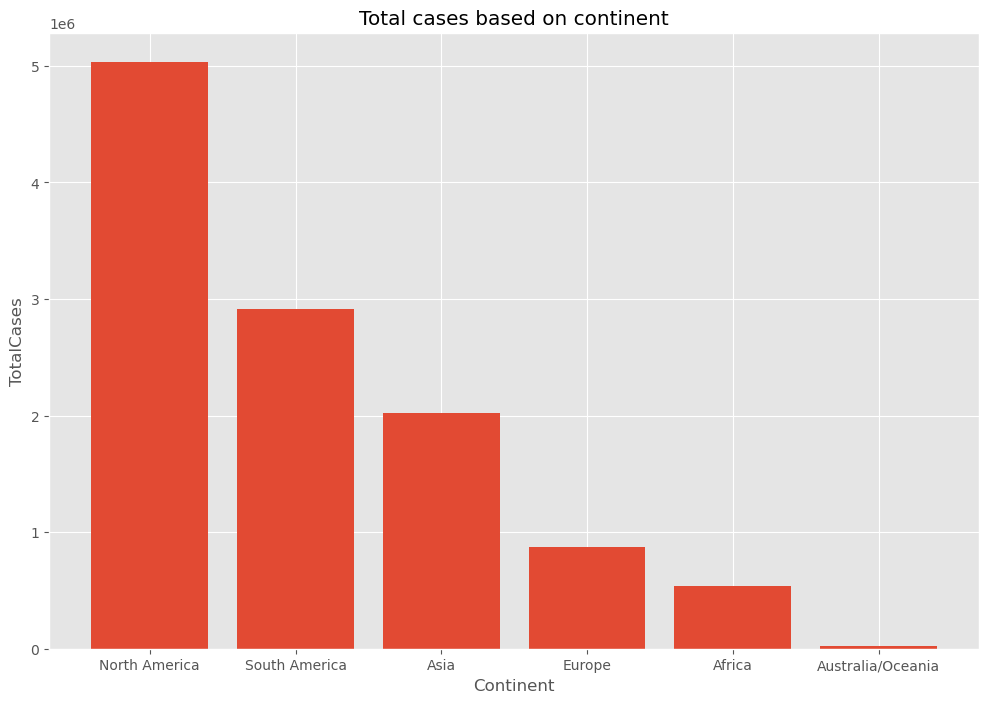

```python
#data visualization (Bar chart)

plt.bar(df['Continent'], (df['TotalCases']))
plt.title('Total cases based on continent')
plt.xlabel('Continent')
plt.ylabel('TotalCases')
plt.show()
#plt.legend('Africa'==1, 'Asia'==2, 'Europe'==3,North America'==4, 'South America'==5, 'Australia/Oceania'==6)

#comments
# the chart showed that the total number of cases was in North America and the least found in Australia/Oceania
```

```python
# #data visualization (Pie chart)
# plt.pie(['Continent'])
# plt.show()
```

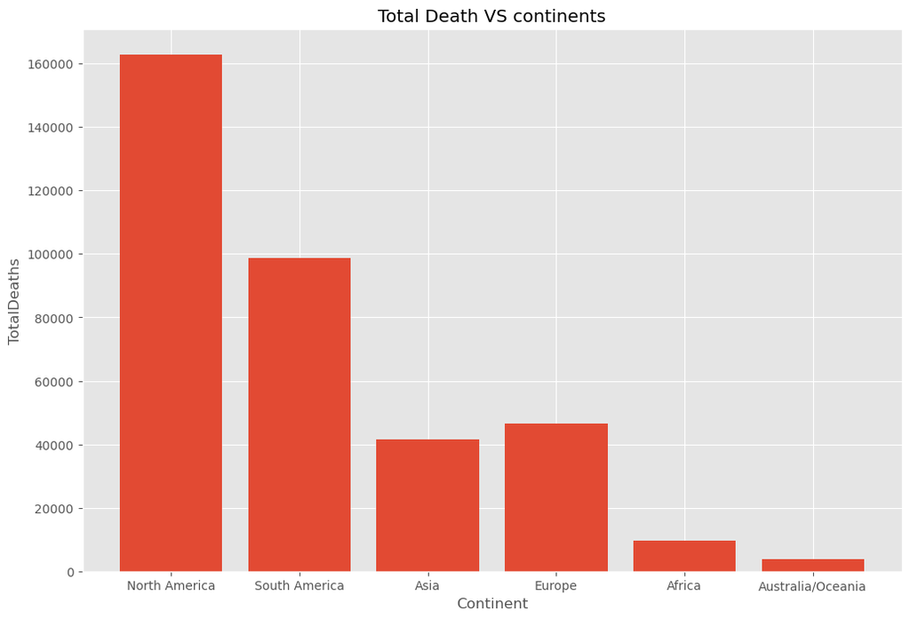

```python
plt.bar(df['Continent'], (df['TotalDeaths']))
plt.title('Total Death VS continents')
plt.xlabel('Continent')
plt.ylabel('TotalDeaths')
plt.show()

#comments
# the chart showed that the total number of deaths was in North America and the least found in Australia/Oceania
```

```python
#data transformation
df['Continent']=df['Continent'].map({'Africa':1,'Asia':2, 'Europe':3, 'North America':4, 'South America':5, 'Australia/Oceania':6})
```

```python
df
```

|  | Country/Region | Continent | Population | TotalCases | NewCases | TotalDeaths | NewDeaths | TotalRecovered | NewRecovered | ActiveCases | Serious,Critical | Tot Cases/1M pop | Deaths/1M pop | TotalTests | Tests/1M pop | WHO Region |
| --- | --- | --- | --- | --- | --- | --- | --- | --- | --- | --- | --- | --- | --- | --- | --- | --- |
| 0 | USA | 4 | 3.311981e+08 | 5032179 | 1980.5 | 162804.000000 | 300.0 | 2576668.0 | 1706.0 | 2292707.0 | 18296.000000 | 15194.0 | 492.000000 | 6.313960e+07 | 190640.000000 | Americas |
| 1 | Brazil | 5 | 2.127107e+08 | 2917562 | 1980.5 | 98644.000000 | 300.0 | 2047660.0 | 1706.0 | 771258.0 | 8318.000000 | 13716.0 | 464.000000 | 1.320619e+07 | 62085.000000 | Americas |
| 2 | India | 2 | 1.381345e+09 | 2025409 | 1980.5 | 41638.000000 | 300.0 | 1377384.0 | 1706.0 | 606387.0 | 8944.000000 | 1466.0 | 30.000000 | 2.214935e+07 | 16035.000000 | South-EastAsia |
| 3 | Russia | 3 | 1.459409e+08 | 871894 | 1980.5 | 14606.000000 | 300.0 | 676357.0 | 1706.0 | 180931.0 | 2300.000000 | 5974.0 | 100.000000 | 2.971691e+07 | 203623.000000 | Europe |
| 4 | South Africa | 1 | 5.938157e+07 | 538184 | 1980.5 | 9604.000000 | 300.0 | 387316.0 | 1706.0 | 141264.0 | 539.000000 | 9063.0 | 162.000000 | 3.149807e+06 | 53044.000000 | Africa |
| ... | ... | ... | ... | ... | ... | ... | ... | ... | ... | ... | ... | ... | ... | ... | ... | ... |
| 204 | Montserrat | 4 | 4.992000e+03 | 13 | 1980.5 | 1.000000 | 300.0 | 10.0 | 1706.0 | 2.0 | 534.393443 | 2604.0 | 200.000000 | 6.100000e+01 | 12220.000000 | NaN |
| 205 | Caribbean Netherlands | 4 | 2.624700e+04 | 13 | 1980.5 | 3792.590426 | 300.0 | 7.0 | 1706.0 | 6.0 | 534.393443 | 495.0 | 98.681176 | 4.240000e+02 | 16154.000000 | NaN |
| 206 | Falkland Islands | 5 | 3.489000e+03 | 13 | 1980.5 | 3792.590426 | 300.0 | 13.0 | 1706.0 | 0.0 | 534.393443 | 3726.0 | 98.681176 | 1.816000e+03 | 520493.000000 | NaN |
| 207 | Vatican City | 3 | 8.010000e+02 | 12 | 1980.5 | 3792.590426 | 300.0 | 12.0 | 1706.0 | 0.0 | 534.393443 | 14981.0 | 98.681176 | 1.402405e+06 | 83959.366492 | Europe |
| 208 | Western Sahara | 1 | 5.986820e+05 | 10 | 1980.5 | 1.000000 | 300.0 | 8.0 | 1706.0 | 1.0 | 534.393443 | 17.0 | 2.000000 | 1.402405e+06 | 83959.366492 | Africa |

209 rows × 16 columns

```python
continent_sum= df['Continent'].value_counts()
```

```python
continent_sum
```

```
Continent
1    58
2    48
3    48
4    35
5    14
6     6
Name: count, dtype: int64
```

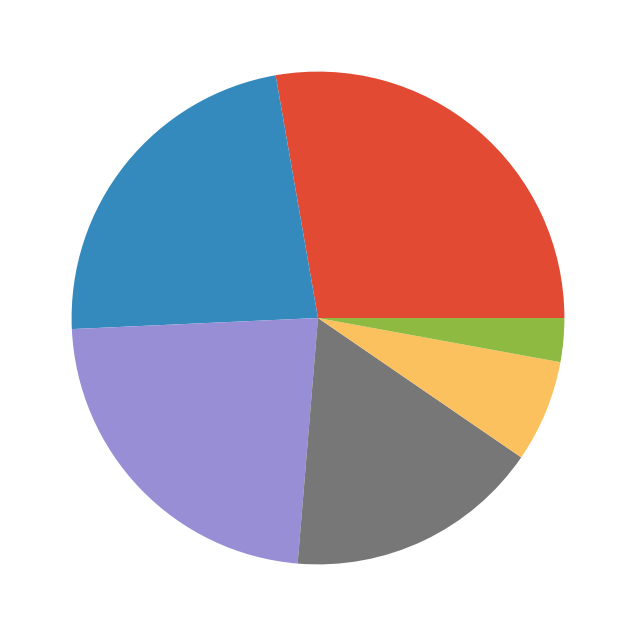

```python
# #data visualization (Pie chart)
plt.pie(continent_sum)
e=(0.2, 0, 0, 0, 0, 0)
plt.show()
```

the above pie chart shows that Africa has the highest number of country affected.

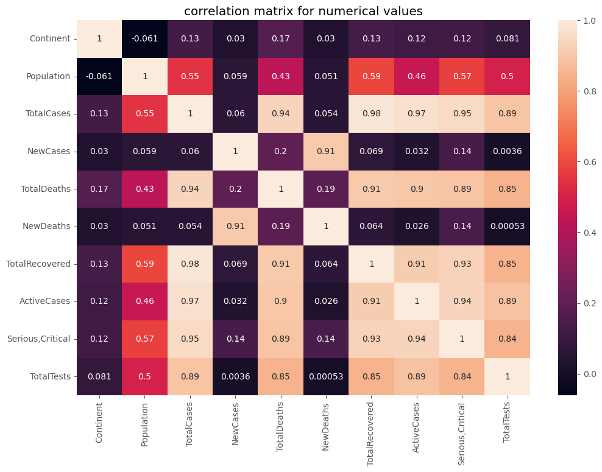

```python
#data visualization using seaborn
correlation_matrix= df[["Continent", 'Population', 'TotalCases', 'NewCases', 'TotalDeaths', 'NewDeaths','TotalRecovered', 'ActiveCases', 'Serious,Critical','TotalTests']].corr(method='pearson')
plt.title('correlation matrix for numerical values')
plt.xlabel('Covid 19 parameters')
plt.ylabel('Covid 19 parameters')

sns.heatmap(correlation_matrix, annot=True )
```

some insights from the correlation test

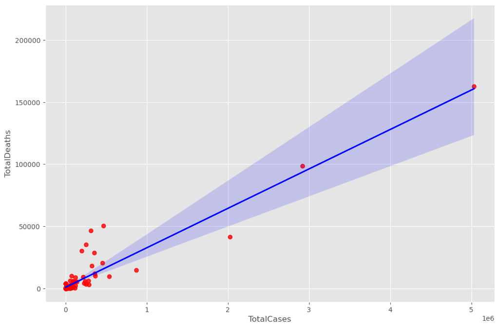

```python
#plotting Total cases vs total deaths using seaborn
sns.regplot(x= 'TotalCases', y= 'TotalDeaths', data=df, scatter_kws={'color':'red'}, line_kws={'color': 'blue'})
```

the regression analysis showed that There was astrong correlation between total cases and total deaths

```python
#SECOND DATASET
df_day_wise = pd.read_csv(r'C:\Users\USER\Desktop\codschooadf\dataSets\day_wise (2).csv')
```

```python
df_day_wise.head()
```

|  | Date | Confirmed | Deaths | Recovered | Active | New cases | New deaths | New recovered | Deaths / 100 Cases | Recovered / 100 Cases | Deaths / 100 Recovered | No. of countries |
| --- | --- | --- | --- | --- | --- | --- | --- | --- | --- | --- | --- | --- |
| 0 | 2020-01-22 | 555 | 17 | 28 | 510 | 0 | 0 | 0 | 3.06 | 5.05 | 60.71 | 6 |
| 1 | 2020-01-23 | 654 | 18 | 30 | 606 | 99 | 1 | 2 | 2.75 | 4.59 | 60.00 | 8 |
| 2 | 2020-01-24 | 941 | 26 | 36 | 879 | 287 | 8 | 6 | 2.76 | 3.83 | 72.22 | 9 |
| 3 | 2020-01-25 | 1434 | 42 | 39 | 1353 | 493 | 16 | 3 | 2.93 | 2.72 | 107.69 | 11 |
| 4 | 2020-01-26 | 2118 | 56 | 52 | 2010 | 684 | 14 | 13 | 2.64 | 2.46 | 107.69 | 13 |

```python
#checking for missing values
df_day_wise.isnull().sum()
```

```
Date                      0
Confirmed                 0
Deaths                    0
Recovered                 0
Active                    0
New cases                 0
New deaths                0
New recovered             0
Deaths / 100 Cases        0
Recovered / 100 Cases     0
Deaths / 100 Recovered    0
No. of countries          0
dtype: int64
```

no missing value

```python
df_day_wise.describe()
```

|  | Confirmed | Deaths | Recovered | Active | New cases | New deaths | New recovered | Deaths / 100 Cases | Recovered / 100 Cases | Deaths / 100 Recovered | No. of countries |
| --- | --- | --- | --- | --- | --- | --- | --- | --- | --- | --- | --- |
| count | 1.880000e+02 | 188.000000 | 1.880000e+02 | 1.880000e+02 | 188.000000 | 188.000000 | 188.000000 | 188.000000 | 188.000000 | 188.000000 | 188.000000 |
| mean | 4.406960e+06 | 230770.760638 | 2.066001e+06 | 2.110188e+06 | 87771.021277 | 3478.824468 | 50362.015957 | 4.860638 | 34.343936 | 22.104521 | 144.351064 |
| std | 4.757988e+06 | 217929.094183 | 2.627976e+06 | 1.969670e+06 | 75295.293255 | 2537.735652 | 56090.892479 | 1.579541 | 16.206159 | 22.568307 | 65.175979 |
| min | 5.550000e+02 | 17.000000 | 2.800000e+01 | 5.100000e+02 | 0.000000 | 0.000000 | 0.000000 | 2.040000 | 1.710000 | 6.260000 | 6.000000 |
| 25% | 1.121910e+05 | 3935.000000 | 6.044125e+04 | 5.864175e+04 | 5568.500000 | 250.750000 | 2488.250000 | 3.510000 | 22.785000 | 9.650000 | 101.250000 |
| 50% | 2.848733e+06 | 204190.000000 | 7.847840e+05 | 1.859759e+06 | 81114.000000 | 4116.000000 | 30991.500000 | 4.850000 | 35.680000 | 15.380000 | 184.000000 |
| 75% | 7.422046e+06 | 418634.500000 | 3.416396e+06 | 3.587015e+06 | 131502.500000 | 5346.000000 | 79706.250000 | 6.297500 | 48.945000 | 25.342500 | 187.000000 |
| max | 1.648048e+07 | 654036.000000 | 9.468087e+06 | 6.358362e+06 | 282756.000000 | 9966.000000 | 284394.000000 | 7.180000 | 57.450000 | 134.430000 | 187.000000 |

```python
#to check for duplicate values
duplicate= df_day_wise.duplicated()
```

```python
duplicate
```

```
0      False
1      False
2      False
3      False
4      False
       ...
183    False
184    False
185    False
186    False
187    False
Length: 188, dtype: bool
```

no duplicated value

```python
df_day_wise
```

|  | Date | Confirmed | Deaths | Recovered | Active | New cases | New deaths | New recovered | Deaths / 100 Cases | Recovered / 100 Cases | Deaths / 100 Recovered | No. of countries |
| --- | --- | --- | --- | --- | --- | --- | --- | --- | --- | --- | --- | --- |
| 0 | 2020-01-22 | 555 | 17 | 28 | 510 | 0 | 0 | 0 | 3.06 | 5.05 | 60.71 | 6 |
| 1 | 2020-01-23 | 654 | 18 | 30 | 606 | 99 | 1 | 2 | 2.75 | 4.59 | 60.00 | 8 |
| 2 | 2020-01-24 | 941 | 26 | 36 | 879 | 287 | 8 | 6 | 2.76 | 3.83 | 72.22 | 9 |
| 3 | 2020-01-25 | 1434 | 42 | 39 | 1353 | 493 | 16 | 3 | 2.93 | 2.72 | 107.69 | 11 |
| 4 | 2020-01-26 | 2118 | 56 | 52 | 2010 | 684 | 14 | 13 | 2.64 | 2.46 | 107.69 | 13 |
| ... | ... | ... | ... | ... | ... | ... | ... | ... | ... | ... | ... | ... |
| 183 | 2020-07-23 | 15510481 | 633506 | 8710969 | 6166006 | 282756 | 9966 | 169714 | 4.08 | 56.16 | 7.27 | 187 |
| 184 | 2020-07-24 | 15791645 | 639650 | 8939705 | 6212290 | 281164 | 6144 | 228736 | 4.05 | 56.61 | 7.16 | 187 |
| 185 | 2020-07-25 | 16047190 | 644517 | 9158743 | 6243930 | 255545 | 4867 | 219038 | 4.02 | 57.07 | 7.04 | 187 |
| 186 | 2020-07-26 | 16251796 | 648621 | 9293464 | 6309711 | 204606 | 4104 | 134721 | 3.99 | 57.18 | 6.98 | 187 |
| 187 | 2020-07-27 | 16480485 | 654036 | 9468087 | 6358362 | 228693 | 5415 | 174623 | 3.97 | 57.45 | 6.91 | 187 |

188 rows × 12 columns

```python
#PERFORMING FEATURE ENGINEERING
df_day_wise['percent_Death']= (df_day_wise['Deaths']/df_day_wise['Confirmed'])*100
df_day_wise['percent_Recovered']= (df_day_wise['Recovered']/df_day_wise['Confirmed'])*100
df_day_wise['percent_Active']= (df_day_wise['Active']/df_day_wise['Confirmed'])*100
```

```python
df_day_wise
```

|  | Date | Confirmed | Deaths | Recovered | Active | New cases | New deaths | New recovered | Deaths / 100 Cases | Recovered / 100 Cases | Deaths / 100 Recovered | No. of countries | percent_Death | percent_Recovered | percent_Active |
| --- | --- | --- | --- | --- | --- | --- | --- | --- | --- | --- | --- | --- | --- | --- | --- |
| 0 | 2020-01-22 | 555 | 17 | 28 | 510 | 0 | 0 | 0 | 3.06 | 5.05 | 60.71 | 6 | 3.063063 | 5.045045 | 91.891892 |
| 1 | 2020-01-23 | 654 | 18 | 30 | 606 | 99 | 1 | 2 | 2.75 | 4.59 | 60.00 | 8 | 2.752294 | 4.587156 | 92.660550 |
| 2 | 2020-01-24 | 941 | 26 | 36 | 879 | 287 | 8 | 6 | 2.76 | 3.83 | 72.22 | 9 | 2.763018 | 3.825717 | 93.411265 |
| 3 | 2020-01-25 | 1434 | 42 | 39 | 1353 | 493 | 16 | 3 | 2.93 | 2.72 | 107.69 | 11 | 2.928870 | 2.719665 | 94.351464 |
| 4 | 2020-01-26 | 2118 | 56 | 52 | 2010 | 684 | 14 | 13 | 2.64 | 2.46 | 107.69 | 13 | 2.644004 | 2.455146 | 94.900850 |
| ... | ... | ... | ... | ... | ... | ... | ... | ... | ... | ... | ... | ... | ... | ... | ... |
| 183 | 2020-07-23 | 15510481 | 633506 | 8710969 | 6166006 | 282756 | 9966 | 169714 | 4.08 | 56.16 | 7.27 | 187 | 4.084374 | 56.161824 | 39.753803 |
| 184 | 2020-07-24 | 15791645 | 639650 | 8939705 | 6212290 | 281164 | 6144 | 228736 | 4.05 | 56.61 | 7.16 | 187 | 4.050560 | 56.610347 | 39.339094 |
| 185 | 2020-07-25 | 16047190 | 644517 | 9158743 | 6243930 | 255545 | 4867 | 219038 | 4.02 | 57.07 | 7.04 | 187 | 4.016385 | 57.073812 | 38.909803 |
| 186 | 2020-07-26 | 16251796 | 648621 | 9293464 | 6309711 | 204606 | 4104 | 134721 | 3.99 | 57.18 | 6.98 | 187 | 3.991073 | 57.184228 | 38.824700 |
| 187 | 2020-07-27 | 16480485 | 654036 | 9468087 | 6358362 | 228693 | 5415 | 174623 | 3.97 | 57.45 | 6.91 | 187 | 3.968548 | 57.450293 | 38.581158 |

188 rows × 15 columns

```python
#data standardization
#df_day_wise['standardized_dates'] = pd.to_datetime(df_day_wise['Date'], errors='coerce', dayfirst=True)
```

[output not shown]

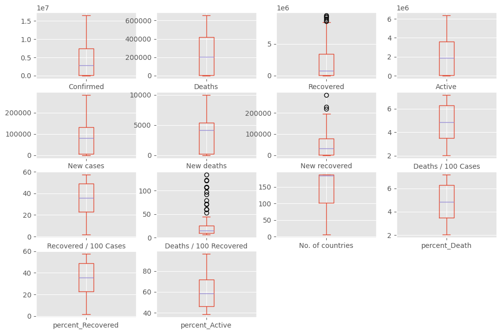

```python
#TO SHOW OUTLIERS
df_day_wise.plot(kind='box', subplots= True, layout= (4, 4 ))
plt.show
```

There are so many outliers in Death/100 recovered while other parameters have little or no outliers

```python
df_covid_19_clean_complete = pd.read_csv(r'C:\Users\USER\Desktop\codschooadf\dataSets\covid_19_clean_complete.csv')
```

```python
df_covid_19_clean_complete
```

|  | Province/State | Country/Region | Lat | Long | Date | Confirmed | Deaths | Recovered | Active | WHO Region |
| --- | --- | --- | --- | --- | --- | --- | --- | --- | --- | --- |
| 0 | NaN | Afghanistan | 33.939110 | 67.709953 | 2020-01-22 | 0 | 0 | 0 | 0 | Eastern Mediterranean |
| 1 | NaN | Albania | 41.153300 | 20.168300 | 2020-01-22 | 0 | 0 | 0 | 0 | Europe |
| 2 | NaN | Algeria | 28.033900 | 1.659600 | 2020-01-22 | 0 | 0 | 0 | 0 | Africa |
| 3 | NaN | Andorra | 42.506300 | 1.521800 | 2020-01-22 | 0 | 0 | 0 | 0 | Europe |
| 4 | NaN | Angola | -11.202700 | 17.873900 | 2020-01-22 | 0 | 0 | 0 | 0 | Africa |
| ... | ... | ... | ... | ... | ... | ... | ... | ... | ... | ... |
| 49063 | NaN | Sao Tome and Principe | 0.186400 | 6.613100 | 2020-07-27 | 865 | 14 | 734 | 117 | Africa |
| 49064 | NaN | Yemen | 15.552727 | 48.516388 | 2020-07-27 | 1691 | 483 | 833 | 375 | Eastern Mediterranean |
| 49065 | NaN | Comoros | -11.645500 | 43.333300 | 2020-07-27 | 354 | 7 | 328 | 19 | Africa |
| 49066 | NaN | Tajikistan | 38.861000 | 71.276100 | 2020-07-27 | 7235 | 60 | 6028 | 1147 | Europe |
| 49067 | NaN | Lesotho | -29.610000 | 28.233600 | 2020-07-27 | 505 | 12 | 128 | 365 | Africa |

49068 rows × 10 columns

```python
#checking for missing values
df_covid_19_clean_complete.isnull().sum()
```

```
Province/State    34404
Country/Region        0
Lat                   0
Long                  0
Date                  0
Confirmed             0
Deaths                0
Recovered             0
Active                0
WHO Region            0
dtype: int64
```

```python
#data cleaning
df_covid_19_clean_complete=df_covid_19_clean_complete.drop(['Province/State'], axis=1)
```

```python
df_covid_19_clean_complete.isnull().sum()
```

```
Country/Region    0
Lat               0
Long              0
Date              0
Confirmed         0
Deaths            0
Recovered         0
Active            0
WHO Region        0
dtype: int64
```

```python
df_covid_19_clean_complete['WHO Region'].value_counts()
```

```
WHO Region
Europe                   15040
Western Pacific          10340
Africa                    9024
Americas                  8648
Eastern Mediterranean     4136
South-East Asia           1880
Name: count, dtype: int64
```

```python
#data visualization (Bar chart)

# plt.bar(df_covid_19_clean_complete['WHO Region'], (df_covid_19_clean_complete['Deaths']))
# plt.title('Deaths based on WHO Region ')
# plt.xlabel('WHO Region')
# plt.ylabel('Deaths')
# plt.show()
```

```python
WHO_Region_sum= df_covid_19_clean_complete['WHO Region'].value_counts()
```

```python
WHO_Region_sum
```

```
WHO Region
Europe                   15040
Western Pacific          10340
Africa                    9024
Americas                  8648
Eastern Mediterranean     4136
South-East Asia           1880
Name: count, dtype: int64
```

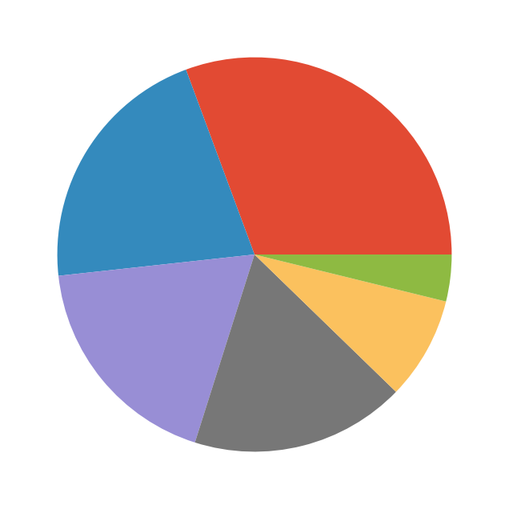

```python
#Data Visualization (pie chart)
plt.pie(WHO_Region_sum)
# e=(0.2, 0, 0, 0, 0, 0)
plt.show()
```

```python
#data transformation
df_covid_19_clean_complete['WHO Region']=df_covid_19_clean_complete['WHO Region'].map({'Europe':1,'Western Pacific':2, 'Africa':3, 'Americas':4, 'Eastern Mediterranean':5, 'South-East Asia':6})
```

```python
df_covid_19_clean_complete
```

|  | Country/Region | Lat | Long | Date | Confirmed | Deaths | Recovered | Active | WHO Region |
| --- | --- | --- | --- | --- | --- | --- | --- | --- | --- |
| 0 | Afghanistan | 33.939110 | 67.709953 | 2020-01-22 | 0 | 0 | 0 | 0 | 5 |
| 1 | Albania | 41.153300 | 20.168300 | 2020-01-22 | 0 | 0 | 0 | 0 | 1 |
| 2 | Algeria | 28.033900 | 1.659600 | 2020-01-22 | 0 | 0 | 0 | 0 | 3 |
| 3 | Andorra | 42.506300 | 1.521800 | 2020-01-22 | 0 | 0 | 0 | 0 | 1 |
| 4 | Angola | -11.202700 | 17.873900 | 2020-01-22 | 0 | 0 | 0 | 0 | 3 |
| ... | ... | ... | ... | ... | ... | ... | ... | ... | ... |
| 49063 | Sao Tome and Principe | 0.186400 | 6.613100 | 2020-07-27 | 865 | 14 | 734 | 117 | 3 |
| 49064 | Yemen | 15.552727 | 48.516388 | 2020-07-27 | 1691 | 483 | 833 | 375 | 5 |
| 49065 | Comoros | -11.645500 | 43.333300 | 2020-07-27 | 354 | 7 | 328 | 19 | 3 |
| 49066 | Tajikistan | 38.861000 | 71.276100 | 2020-07-27 | 7235 | 60 | 6028 | 1147 | 1 |
| 49067 | Lesotho | -29.610000 | 28.233600 | 2020-07-27 | 505 | 12 | 128 | 365 | 3 |

49068 rows × 9 columns

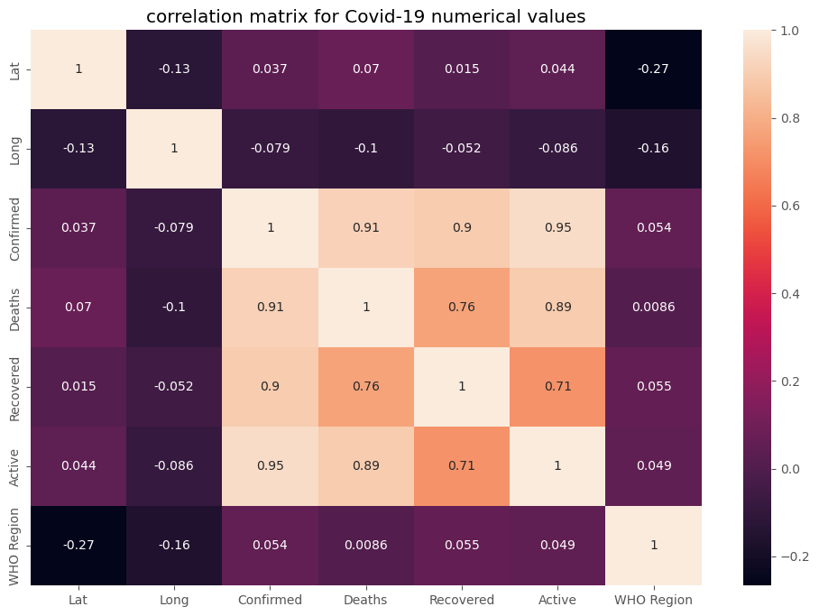

```python
#data visualization using seaborn
correlation_matrix= df_covid_19_clean_complete[["Lat", 'Long', 'Confirmed', 'Deaths', 'Recovered', 'Active','WHO Region']].corr(method='pearson')
plt.title('correlation matrix for Covid-19 numerical values')
plt.xlabel('Covid 19 parameters')
plt.ylabel('Covid 19 parameters')

sns.heatmap(correlation_matrix, annot=True )
```

from the correlation analysis above, showed that there is a week correlation between Lat, long and the comfirmed, death and recovered, which means tjhe latitude and longitude of the region has nothing to do with Covid-19 occurrence. also WHO region has no correlation with the comfirmed, the death and thej recovered. the correlation chat showed that, there is a strong correlation between the comfirmed and the death which means the higher the comfired the higher the death rate. Also, a strong correlation correlation between the comfirmed and recovered. i.e the higher the comfirmed, the higher the recovered and vice versa. Given below are the regression

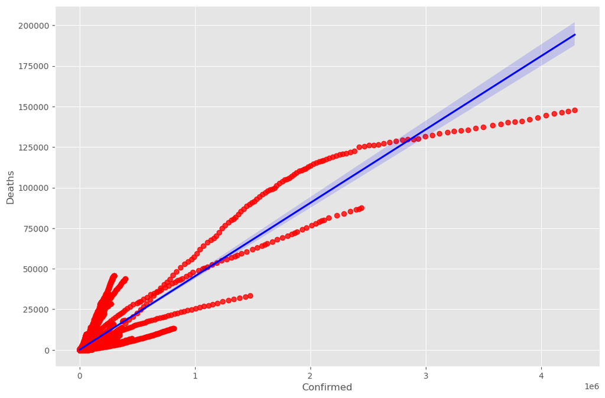

```python
#plotting Confirmed cases vs deaths using seaborn
sns.regplot(x= 'Confirmed', y= 'Deaths', data=df_covid_19_clean_complete, scatter_kws={'color':'red'}, line_kws={'color': 'blue'})
```

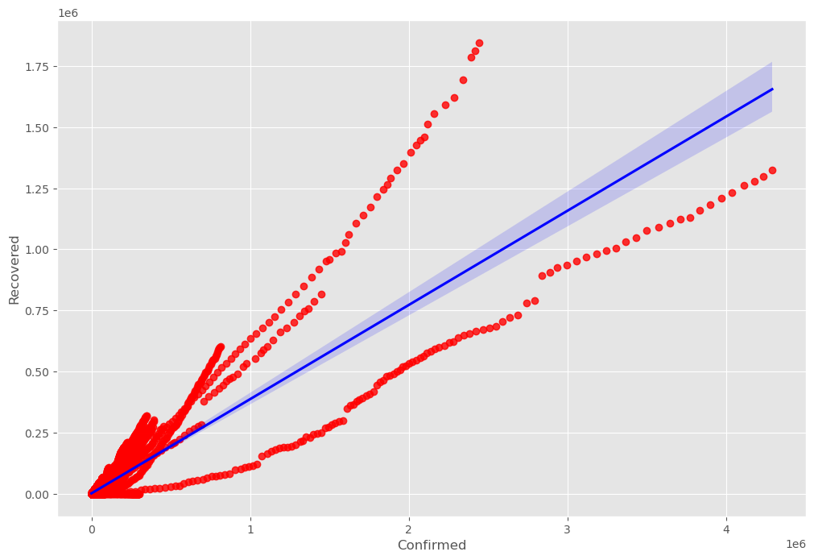

```python
#plotting Confirmed cases vs deaths using seaborn
sns.regplot(x= 'Confirmed', y= 'Recovered', data=df_covid_19_clean_complete, scatter_kws={'color':'red'}, line_kws={'color': 'blue'})
```

```python
# creating model using Linear regression

df_worldometer_data
```

|  | Country/Region | Continent | Population | TotalCases | NewCases | TotalDeaths | NewDeaths | TotalRecovered | NewRecovered | ActiveCases | Serious,Critical | Tot Cases/1M pop | Deaths/1M pop | TotalTests | Tests/1M pop | WHO Region |
| --- | --- | --- | --- | --- | --- | --- | --- | --- | --- | --- | --- | --- | --- | --- | --- | --- |
| 0 | USA | 4 | 3.311981e+08 | 5032179 | 1980.5 | 162804.000000 | 300.0 | 2576668.0 | 1706.0 | 2292707.0 | 18296.000000 | 15194.0 | 492.000000 | 6.313960e+07 | 190640.000000 | Americas |
| 1 | Brazil | 5 | 2.127107e+08 | 2917562 | 1980.5 | 98644.000000 | 300.0 | 2047660.0 | 1706.0 | 771258.0 | 8318.000000 | 13716.0 | 464.000000 | 1.320619e+07 | 62085.000000 | Americas |
| 2 | India | 2 | 1.381345e+09 | 2025409 | 1980.5 | 41638.000000 | 300.0 | 1377384.0 | 1706.0 | 606387.0 | 8944.000000 | 1466.0 | 30.000000 | 2.214935e+07 | 16035.000000 | South-EastAsia |
| 3 | Russia | 3 | 1.459409e+08 | 871894 | 1980.5 | 14606.000000 | 300.0 | 676357.0 | 1706.0 | 180931.0 | 2300.000000 | 5974.0 | 100.000000 | 2.971691e+07 | 203623.000000 | Europe |
| 4 | South Africa | 1 | 5.938157e+07 | 538184 | 1980.5 | 9604.000000 | 300.0 | 387316.0 | 1706.0 | 141264.0 | 539.000000 | 9063.0 | 162.000000 | 3.149807e+06 | 53044.000000 | Africa |
| ... | ... | ... | ... | ... | ... | ... | ... | ... | ... | ... | ... | ... | ... | ... | ... | ... |
| 204 | Montserrat | 4 | 4.992000e+03 | 13 | 1980.5 | 1.000000 | 300.0 | 10.0 | 1706.0 | 2.0 | 534.393443 | 2604.0 | 200.000000 | 6.100000e+01 | 12220.000000 | NaN |
| 205 | Caribbean Netherlands | 4 | 2.624700e+04 | 13 | 1980.5 | 3792.590426 | 300.0 | 7.0 | 1706.0 | 6.0 | 534.393443 | 495.0 | 98.681176 | 4.240000e+02 | 16154.000000 | NaN |
| 206 | Falkland Islands | 5 | 3.489000e+03 | 13 | 1980.5 | 3792.590426 | 300.0 | 13.0 | 1706.0 | 0.0 | 534.393443 | 3726.0 | 98.681176 | 1.816000e+03 | 520493.000000 | NaN |
| 207 | Vatican City | 3 | 8.010000e+02 | 12 | 1980.5 | 3792.590426 | 300.0 | 12.0 | 1706.0 | 0.0 | 534.393443 | 14981.0 | 98.681176 | 1.402405e+06 | 83959.366492 | Europe |
| 208 | Western Sahara | 1 | 5.986820e+05 | 10 | 1980.5 | 1.000000 | 300.0 | 8.0 | 1706.0 | 1.0 | 534.393443 | 17.0 | 2.000000 | 1.402405e+06 | 83959.366492 | Africa |

209 rows × 16 columns

```python
df_worldometer_data=df_worldometer_data.drop(['Country/Region'], axis=1)
```

```python
df_worldometer_data
```

|  | Continent | Population | TotalCases | NewCases | TotalDeaths | NewDeaths | TotalRecovered | NewRecovered | ActiveCases | Serious,Critical | Tot Cases/1M pop | Deaths/1M pop | TotalTests | Tests/1M pop | WHO Region |
| --- | --- | --- | --- | --- | --- | --- | --- | --- | --- | --- | --- | --- | --- | --- | --- |
| 0 | 4 | 3.311981e+08 | 5032179 | 1980.5 | 162804.000000 | 300.0 | 2576668.0 | 1706.0 | 2292707.0 | 18296.000000 | 15194.0 | 492.000000 | 6.313960e+07 | 190640.000000 | Americas |
| 1 | 5 | 2.127107e+08 | 2917562 | 1980.5 | 98644.000000 | 300.0 | 2047660.0 | 1706.0 | 771258.0 | 8318.000000 | 13716.0 | 464.000000 | 1.320619e+07 | 62085.000000 | Americas |
| 2 | 2 | 1.381345e+09 | 2025409 | 1980.5 | 41638.000000 | 300.0 | 1377384.0 | 1706.0 | 606387.0 | 8944.000000 | 1466.0 | 30.000000 | 2.214935e+07 | 16035.000000 | South-EastAsia |
| 3 | 3 | 1.459409e+08 | 871894 | 1980.5 | 14606.000000 | 300.0 | 676357.0 | 1706.0 | 180931.0 | 2300.000000 | 5974.0 | 100.000000 | 2.971691e+07 | 203623.000000 | Europe |
| 4 | 1 | 5.938157e+07 | 538184 | 1980.5 | 9604.000000 | 300.0 | 387316.0 | 1706.0 | 141264.0 | 539.000000 | 9063.0 | 162.000000 | 3.149807e+06 | 53044.000000 | Africa |
| ... | ... | ... | ... | ... | ... | ... | ... | ... | ... | ... | ... | ... | ... | ... | ... |
| 204 | 4 | 4.992000e+03 | 13 | 1980.5 | 1.000000 | 300.0 | 10.0 | 1706.0 | 2.0 | 534.393443 | 2604.0 | 200.000000 | 6.100000e+01 | 12220.000000 | NaN |
| 205 | 4 | 2.624700e+04 | 13 | 1980.5 | 3792.590426 | 300.0 | 7.0 | 1706.0 | 6.0 | 534.393443 | 495.0 | 98.681176 | 4.240000e+02 | 16154.000000 | NaN |
| 206 | 5 | 3.489000e+03 | 13 | 1980.5 | 3792.590426 | 300.0 | 13.0 | 1706.0 | 0.0 | 534.393443 | 3726.0 | 98.681176 | 1.816000e+03 | 520493.000000 | NaN |
| 207 | 3 | 8.010000e+02 | 12 | 1980.5 | 3792.590426 | 300.0 | 12.0 | 1706.0 | 0.0 | 534.393443 | 14981.0 | 98.681176 | 1.402405e+06 | 83959.366492 | Europe |
| 208 | 1 | 5.986820e+05 | 10 | 1980.5 | 1.000000 | 300.0 | 8.0 | 1706.0 | 1.0 | 534.393443 | 17.0 | 2.000000 | 1.402405e+06 | 83959.366492 | Africa |

209 rows × 15 columns

```python
df_worldometer_data.isnull().sum()
```

```
Continent            0
Population           0
TotalCases           0
NewCases             0
TotalDeaths          0
NewDeaths            0
TotalRecovered       0
NewRecovered         0
ActiveCases          0
Serious,Critical     0
Tot Cases/1M pop     0
Deaths/1M pop        0
TotalTests           0
Tests/1M pop         0
WHO Region          25
dtype: int64
```

```python
df_worldometer_data['WHO Region'].value_counts()
```

```
WHO Region
Europe                  55
Africa                  47
Americas                35
EasternMediterranean    22
WesternPacific          15
South-EastAsia          10
Name: count, dtype: int64
```

```python
#data cleaning
df_worldometer_data['WHO Region']=df_worldometer_data['WHO Region'].fillna(df_worldometer_data['WHO Region'].mode()[0])
```

```python
df_worldometer_data.isnull().sum()
```

```
Continent           0
Population          0
TotalCases          0
NewCases            0
TotalDeaths         0
NewDeaths           0
TotalRecovered      0
NewRecovered        0
ActiveCases         0
Serious,Critical    0
Tot Cases/1M pop    0
Deaths/1M pop       0
TotalTests          0
Tests/1M pop        0
WHO Region          0
dtype: int64
```

```python
# DATA TRANSFORMATION
df_worldometer_data['WHO Region']=df_worldometer_data['WHO Region'].map({'Europe':1,'Africa':2, 'Americas':3, 'EasternMediterranean':4, 'WesternPacific':5, 'South-EastAsia':6})
```

```python
df_worldometer_data
```

|  | Continent | Population | TotalCases | NewCases | TotalDeaths | NewDeaths | TotalRecovered | NewRecovered | ActiveCases | Serious,Critical | Tot Cases/1M pop | Deaths/1M pop | TotalTests | Tests/1M pop | WHO Region |
| --- | --- | --- | --- | --- | --- | --- | --- | --- | --- | --- | --- | --- | --- | --- | --- |
| 0 | 4 | 3.311981e+08 | 5032179 | 1980.5 | 162804.000000 | 300.0 | 2576668.0 | 1706.0 | 2292707.0 | 18296.000000 | 15194.0 | 492.000000 | 6.313960e+07 | 190640.000000 | 3 |
| 1 | 5 | 2.127107e+08 | 2917562 | 1980.5 | 98644.000000 | 300.0 | 2047660.0 | 1706.0 | 771258.0 | 8318.000000 | 13716.0 | 464.000000 | 1.320619e+07 | 62085.000000 | 3 |
| 2 | 2 | 1.381345e+09 | 2025409 | 1980.5 | 41638.000000 | 300.0 | 1377384.0 | 1706.0 | 606387.0 | 8944.000000 | 1466.0 | 30.000000 | 2.214935e+07 | 16035.000000 | 6 |
| 3 | 3 | 1.459409e+08 | 871894 | 1980.5 | 14606.000000 | 300.0 | 676357.0 | 1706.0 | 180931.0 | 2300.000000 | 5974.0 | 100.000000 | 2.971691e+07 | 203623.000000 | 1 |
| 4 | 1 | 5.938157e+07 | 538184 | 1980.5 | 9604.000000 | 300.0 | 387316.0 | 1706.0 | 141264.0 | 539.000000 | 9063.0 | 162.000000 | 3.149807e+06 | 53044.000000 | 2 |
| ... | ... | ... | ... | ... | ... | ... | ... | ... | ... | ... | ... | ... | ... | ... | ... |
| 204 | 4 | 4.992000e+03 | 13 | 1980.5 | 1.000000 | 300.0 | 10.0 | 1706.0 | 2.0 | 534.393443 | 2604.0 | 200.000000 | 6.100000e+01 | 12220.000000 | 1 |
| 205 | 4 | 2.624700e+04 | 13 | 1980.5 | 3792.590426 | 300.0 | 7.0 | 1706.0 | 6.0 | 534.393443 | 495.0 | 98.681176 | 4.240000e+02 | 16154.000000 | 1 |
| 206 | 5 | 3.489000e+03 | 13 | 1980.5 | 3792.590426 | 300.0 | 13.0 | 1706.0 | 0.0 | 534.393443 | 3726.0 | 98.681176 | 1.816000e+03 | 520493.000000 | 1 |
| 207 | 3 | 8.010000e+02 | 12 | 1980.5 | 3792.590426 | 300.0 | 12.0 | 1706.0 | 0.0 | 534.393443 | 14981.0 | 98.681176 | 1.402405e+06 | 83959.366492 | 1 |
| 208 | 1 | 5.986820e+05 | 10 | 1980.5 | 1.000000 | 300.0 | 8.0 | 1706.0 | 1.0 | 534.393443 | 17.0 | 2.000000 | 1.402405e+06 | 83959.366492 | 2 |

209 rows × 15 columns

```python
#creating model
Y = df_worldometer_data['NewCases']
```

```python
X =df_worldometer_data.drop(['NewCases'], axis=1)
```

```python
Y
```

```
0      1980.5
1      1980.5
2      1980.5
3      1980.5
4      1980.5
        ...
204    1980.5
205    1980.5
206    1980.5
207    1980.5
208    1980.5
Name: NewCases, Length: 209, dtype: float64
```

```python
X
```

|  | Continent | Population | TotalCases | TotalDeaths | NewDeaths | TotalRecovered | NewRecovered | ActiveCases | Serious,Critical | Tot Cases/1M pop | Deaths/1M pop | TotalTests | Tests/1M pop | WHO Region |
| --- | --- | --- | --- | --- | --- | --- | --- | --- | --- | --- | --- | --- | --- | --- |
| 0 | 4 | 3.311981e+08 | 5032179 | 162804.000000 | 300.0 | 2576668.0 | 1706.0 | 2292707.0 | 18296.000000 | 15194.0 | 492.000000 | 6.313960e+07 | 190640.000000 | 3 |
| 1 | 5 | 2.127107e+08 | 2917562 | 98644.000000 | 300.0 | 2047660.0 | 1706.0 | 771258.0 | 8318.000000 | 13716.0 | 464.000000 | 1.320619e+07 | 62085.000000 | 3 |
| 2 | 2 | 1.381345e+09 | 2025409 | 41638.000000 | 300.0 | 1377384.0 | 1706.0 | 606387.0 | 8944.000000 | 1466.0 | 30.000000 | 2.214935e+07 | 16035.000000 | 6 |
| 3 | 3 | 1.459409e+08 | 871894 | 14606.000000 | 300.0 | 676357.0 | 1706.0 | 180931.0 | 2300.000000 | 5974.0 | 100.000000 | 2.971691e+07 | 203623.000000 | 1 |
| 4 | 1 | 5.938157e+07 | 538184 | 9604.000000 | 300.0 | 387316.0 | 1706.0 | 141264.0 | 539.000000 | 9063.0 | 162.000000 | 3.149807e+06 | 53044.000000 | 2 |
| ... | ... | ... | ... | ... | ... | ... | ... | ... | ... | ... | ... | ... | ... | ... |
| 204 | 4 | 4.992000e+03 | 13 | 1.000000 | 300.0 | 10.0 | 1706.0 | 2.0 | 534.393443 | 2604.0 | 200.000000 | 6.100000e+01 | 12220.000000 | 1 |
| 205 | 4 | 2.624700e+04 | 13 | 3792.590426 | 300.0 | 7.0 | 1706.0 | 6.0 | 534.393443 | 495.0 | 98.681176 | 4.240000e+02 | 16154.000000 | 1 |
| 206 | 5 | 3.489000e+03 | 13 | 3792.590426 | 300.0 | 13.0 | 1706.0 | 0.0 | 534.393443 | 3726.0 | 98.681176 | 1.816000e+03 | 520493.000000 | 1 |
| 207 | 3 | 8.010000e+02 | 12 | 3792.590426 | 300.0 | 12.0 | 1706.0 | 0.0 | 534.393443 | 14981.0 | 98.681176 | 1.402405e+06 | 83959.366492 | 1 |
| 208 | 1 | 5.986820e+05 | 10 | 1.000000 | 300.0 | 8.0 | 1706.0 | 1.0 | 534.393443 | 17.0 | 2.000000 | 1.402405e+06 | 83959.366492 | 2 |

209 rows × 14 columns

```python
from sklearn.model_selection import train_test_split
from sklearn.linear_model import LinearRegression
from sklearn.metrics import mean_squared_error, r2_score

X_train, X_test, Y_train, Y_test= train_test_split(X, Y, test_size= 0.2, random_state=42)
```

```python
model=LinearRegression()
model.fit(X_train, Y_train)
Y_prdict=model.predict(X_test)
```

```python
Y_prdict
```

```
array([1989.71084462, 1945.35532121, 2038.74170583, 2007.31187611,
       1968.8360683 , 1965.91991545, 2023.76795368, 1957.67220128,
       1492.94630115, 1927.7123922 , 1951.85550167, 2022.42604586,
       2012.05133115, 1948.93195248, 2400.05301729, 1964.36784722,
       1974.5747247 , 2049.1953445 , 1947.21452814, 1940.93450892,
       1959.08607549, 1966.63754735, 1955.89434294, 1965.82898441,
       1971.74922657, 1975.82450138, 1955.92365414, 1969.08802114,
       1982.12785993, 2035.15370867, 2008.56320109, 1959.18524653,
       1992.01839453, 1948.85377793, 1973.55867876, 1971.71165325,
       2082.40049849, 1963.54544777, 1995.81105547, 1945.72669935,
       2007.18663896, 1964.89752039])
```

```python
Y_test
```

```
30     1980.5
171    1980.5
84     1980.5
198    1980.5
60     1980.5
155    1980.5
45     1980.5
181    1980.5
9      1980.5
195    1980.5
136    1980.5
186    1980.5
206    1980.5
126    1980.5
15     1980.5
```

[output cut: 28 more lines]

```python
#GETTING THE MEAN SQUARE ERROR
mse = mean_squared_error(Y_test, Y_prdict)
```

```python
mse
```

```
10900.389183814801
```

```python
#TO GET THE ROOT MEAN SQUARE ERROR
rmse = mse ** 0.5
```

```python
rmse
```

```
104.40492892490661
```

```python
from sklearn.ensemble import RandomForestClassifier
from sklearn.datasets import make_classification
```

```python
X, Y = make_classification(n_samples=1000, n_features=20, n_classes=2, random_state=42)
model = RandomForestClassifier()
X_train, X_test, Y_train, Y_test = train_test_split(X, Y, test_size=0.3, random_state=42)
model.fit(X_train, Y_train)
Y_pred1 = model.predict(X_test)
```

```python
# from sklearn.metrics import f1_score
# f1 = f1_score(Y_test, Y_pred)
```